# on which level are players are most likely to fail

```python
import numpy as np
import pandas as pd
import matplotlib.pyplot as plt
import seaborn as sns
data = pd.read_csv("G:\\2020\\level_progress.csv")
data.head()
import scipy.stats as stats
plt.style.use('ggplot')
```

```python
data.shape
```

```
(55826, 5)
```

The dataset contains 55826 rows,and 5 columns

```python
data.describe()
```

|  | level_number |
| --- | --- |
| count | 55826.000000 |
| mean | 5.991778 |
| std | 5.988455 |
| min | 0.000000 |
| 25% | 2.000000 |
| 50% | 4.000000 |
| 75% | 8.000000 |
| max | 49.000000 |

# Analyze by visualizing data

Now we can continue confirming some of our assumptions using visualizations for analyzing the data.

### Basic Histograms

As a starting point, we plot a histogram of the distribution of the number of levels using plt.hist() function in Matplotlib:

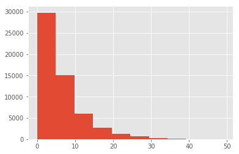

```python
plt.hist(data.level_number);
```

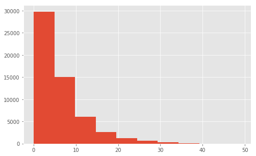

```python
plt.figure(figsize=(8,5)) # Specify the figure size
plt.hist(data.level_number)
plt.show()
```

# KDE Charts

## KDE Plots of More Than One Factor

Then we make the last sets of charts by plotting kdes grouped by factor so that we can visualize the difference in distribution among factor values. Here we separate the data by whether they are 'status' datasets and plot the distribution of level number.

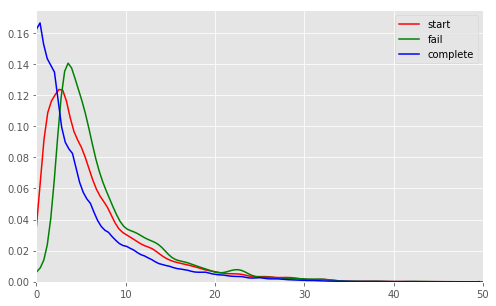

```python
plt.figure(figsize=(8,5))
sns.kdeplot(data.loc[data.status == 'start', 'level_number'], color='red', label='start')
sns.kdeplot(data.loc[data.status == 'fail', 'level_number'], color='green', label='fail')
sns.kdeplot(data.loc[data.status == 'complete', 'level_number'], color='blue', label='complete')

plt.xlim(0, 50) # Limit the view from 0 to 50
plt.show()
```

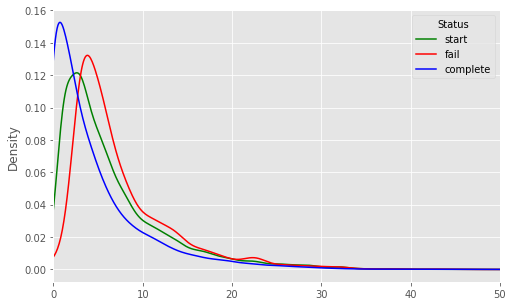

```python
# Do it with Matplotlib
plt.figure(figsize=(8,5))
data.loc[data.status == 'start', 'level_number'].plot.kde(color='green')
data.loc[data.status == 'fail', 'level_number'].plot.kde(color='red')
data.loc[data.status == 'complete', 'level_number'].plot.kde(color='blue')
plt.legend(('start','fail','complete'), title='Status')
plt.xlim(0, 50)
plt.show()
```

It is seen that datasets have more fails between 0 to 25.

The looks of kde plots using Seaborn and Matplotlib are different because they use a different kernel estimate, which is beyond the scope of this notebook.

# Correlating numerical features

Let us start by understanding correlations between numerical features and our solution goal (failure).

A histogram chart is useful for analyzing continous numerical variables where banding or ranges will help identify useful patterns. The histogram can indicate distribution of samples using automatically defined bins or equally ranged bands. This helps us answer questions relating to specific bands (On which level players most likely to fail?)

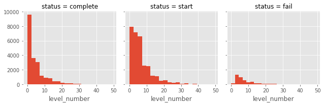

```python
g = sns.FacetGrid(data, col='status')
g.map(plt.hist, 'level_number', bins=20)
```

### Here we need to know on which level there are most likely to fail?

#### Let us look at the status fail.

Here the value lies between 0 to 25 and maximum failure lies between o to 15. And it shows highest fail between 2 to 8 level numbers.

## Conclusion:

From Kde Chart and Correlating histogram chart it is evident that players are most likely to fail between Level 3 to 5.

It is observed hat dataset have more fails between 0 to 25.

## Statistical Analysis

```python
data_df = data.loc[data.status != 'start'].copy()
data_df.shape
```

```
(24717, 5)
```

```python
df =  pd.crosstab(data_df['level_number'], data_df['status'])
print(df.head())
print('\n')
print(df.tail())
```

```
status        complete  fail
level_number
0                 3736    37
1                 3164    20
2                 2671    91
3                 1963   865
4                 1640   475


status        complete  fail
level_number
44                   1     1
45                   2     0
46                   1     0
47                   1     0
48                   1     0
```

It seems freequency are very low and negligible for levels above 30.

```python
df_norm = pd.crosstab(data_df['level_number'],data_df['status'],normalize = 'index').reset_index()
df_norm['total_samples'] = df['complete'] + df['fail']
df_norm.sort_values('complete').head()
```

| status | level_number | complete | fail | total_samples |
| --- | --- | --- | --- | --- |
| 44 | 44 | 0.500000 | 0.500000 | 2 |
| 42 | 42 | 0.500000 | 0.500000 | 4 |
| 35 | 35 | 0.571429 | 0.428571 | 7 |
| 32 | 32 | 0.571429 | 0.428571 | 21 |
| 38 | 38 | 0.600000 | 0.400000 | 5 |

```python
def get_significance(p_val):
    """Receives the p-value and returns string."""
    if not pd.notnull(p_val):
        p_text = 'ns'
    elif p_val > 0.05:
        p_text = "ns"  # above threshold => not significant
    else:
        p_text = 'significant'

    return p_text
```

ChiSquare test for proportions. To check if there is significant association between level_number & status (success/fail).

In the formula, observed is the actual observed count for each category and expected is the expected count based on the distribution of the population for the corresponding category. Let's calculate the chi-squared statistic for our data to illustrate:

H0 (Null hypotheses) : The two categorical variables are independent (no association between the two variables) ( H0: Oi = Ei ). H1 (Alternative hypotheses) = The two categorical variables are dependent (there is an association between the two variables) ( Ha: Oi ≠ Ei ).

### Assumptions:

The two variables are categorical (nominal) and data is randomly sampled.

The levels of variables are mutually exclusive.

The expected frequency count for at least 80% of the cell in a contingency table is at least 5.

The expected frequency count should not be less than 1. Observations should be independent of each other.

Observation data should be frequency counts and not percentages or transformed data.

```python
levels_to_consider = df_norm[df_norm['total_samples'] > 5]['level_number'].tolist()

df_chi = df[df.index.isin(levels_to_consider)].copy()
```

```python
chi2, p, dof, exp = stats.chi2_contingency(df, correction=False)
print('p-value for chi-sqaure test:', p)
```

```
p-value for chi-sqaure test: 0.0
```

Having a low p-value leads us against our initial null hypothesis. In other words the probability of finding the same difference between means as observed or higher values is so low that it's more likely to assume that means are not equal at all.

```python
df_chi['total_samples'] = df_chi['complete'] + df_chi['fail']
```

```python
from statsmodels.stats.proportion import proportions_chisquare_allpairs
r = proportions_chisquare_allpairs(df_chi['complete'], df_chi['total_samples'],
                                   multitest_method = 'simes-hochberg')

g = [eval(t) for t in r.all_pairs_names]
g1, g2 = zip(*g)
rows = list(zip(g1, g2, r.pvals_raw, r.pval_corrected()))
read_df = pd.DataFrame(rows, columns = ['level_1', 'level_2', 'raw_pvalue', 'correct_pvalue'])
read_df.shape
```

```
(630, 4)
```

```python
read_df['result'] = read_df['correct_pvalue'].apply(lambda x:get_significance(x))
```

```python
sd = dict(zip(df_norm['level_number'], df_norm['complete']))
```

```python
sig_df = read_df[read_df['result'] == 'significant'].copy()
sig_df['level1_success_ratio'] = sig_df['level_1'].replace(sd)
sig_df['level2_success_ratio'] = sig_df['level_2'].replace(sd)
sig_df['diff'] = (sig_df['level1_success_ratio'] - sig_df['level2_success_ratio'])
```

```python
sig_df.sort_values('correct_pvalue')
```

|  | level_1 | level_2 | raw_pvalue | correct_pvalue | result | level1_success_ratio | level2_success_ratio | diff |
| --- | --- | --- | --- | --- | --- | --- | --- | --- |
| 2 | 0 | 3 | 3.713181e-263 | 2.339304e-260 | significant | 0.990193 | 0.694130 | 0.296063 |
| 4 | 0 | 5 | 3.560892e-238 | 2.239801e-235 | significant | 0.990193 | 0.704620 | 0.285573 |
| 36 | 1 | 3 | 7.275200e-235 | 4.568826e-232 | significant | 0.993719 | 0.694130 | 0.299588 |
| 5 | 0 | 6 | 3.132988e-220 | 1.964383e-217 | significant | 0.990193 | 0.714693 | 0.275500 |
| 38 | 1 | 5 | 1.464937e-214 | 9.170505e-212 | significant | 0.993719 | 0.704620 | 0.289098 |
| 7 | 0 | 8 | 8.571126e-206 | 5.356954e-203 | significant | 0.990193 | 0.714126 | 0.276068 |
| 39 | 1 | 6 | 4.177612e-200 | 2.606830e-197 | significant | 0.993719 | 0.714693 | 0.279025 |
| 41 | 1 | 8 | 2.733864e-190 | 1.703198e-187 | significant | 0.993719 | 0.714126 | 0.279593 |
| 13 | 0 | 14 | 1.901517e-187 | 1.182743e-184 | significant | 0.990193 | 0.685629 | 0.304565 |
| 47 | 1 | 14 | 4.213256e-184 | 2.616432e-181 | significant | 0.993719 | 0.685629 | 0.308090 |
| 6 | 0 | 7 | 2.142999e-174 | 1.328659e-171 | significant | 0.990193 | 0.754808 | 0.235386 |
| 3 | 0 | 4 | 2.889863e-173 | 1.788825e-170 | significant | 0.990193 | 0.775414 | 0.214780 |
| 56 | 1 | 23 | 2.525810e-169 | 1.560950e-166 | significant | 0.993719 | 0.628571 | 0.365147 |
| 12 | 0 | 13 | 1.438682e-168 | 8.876670e-166 | significant | 0.990193 | 0.719697 | 0.270497 |
| 10 | 0 | 11 | 2.862843e-167 | 1.763511e-164 | significant | 0.990193 | 0.739362 | 0.250832 |
| 46 | 1 | 13 | 3.695344e-165 | 2.272636e-162 | significant | 0.993719 | 0.719697 | 0.274022 |
| 40 | 1 | 7 | 6.760754e-162 | 4.151103e-159 | significant | 0.993719 | 0.754808 | 0.238911 |
| 69 | 2 | 3 | 1.125729e-161 | 6.900719e-159 | significant | 0.967053 | 0.694130 | 0.272923 |
| 44 | 1 | 11 | 2.267377e-160 | 1.387634e-157 | significant | 0.993719 | 0.739362 | 0.254357 |
| 37 | 1 | 4 | 1.519426e-157 | 9.283695e-155 | significant | 0.993719 | 0.775414 | 0.218305 |
| 22 | 0 | 23 | 3.156618e-153 | 1.925537e-150 | significant | 0.990193 | 0.628571 | 0.361622 |
| 55 | 1 | 22 | 4.316234e-146 | 2.628587e-143 | significant | 0.993719 | 0.672566 | 0.321152 |
| 8 | 0 | 9 | 1.630524e-145 | 9.913586e-143 | significant | 0.990193 | 0.774101 | 0.216093 |
| 11 | 0 | 12 | 3.514138e-143 | 2.133082e-140 | significant | 0.990193 | 0.758315 | 0.231879 |
| 45 | 1 | 12 | 4.171922e-141 | 2.528184e-138 | significant | 0.993719 | 0.758315 | 0.235404 |
| 50 | 1 | 17 | 5.964043e-141 | 3.608246e-138 | significant | 0.993719 | 0.721393 | 0.272326 |
| 71 | 2 | 5 | 8.324388e-141 | 5.027931e-138 | significant | 0.967053 | 0.704620 | 0.262432 |
| 42 | 1 | 9 | 1.994519e-139 | 1.202695e-136 | significant | 0.993719 | 0.774101 | 0.219618 |
| 16 | 0 | 17 | 3.182512e-133 | 1.915872e-130 | significant | 0.990193 | 0.721393 | 0.268800 |
| 9 | 0 | 10 | 3.291065e-132 | 1.977930e-129 | significant | 0.990193 | 0.783646 | 0.206548 |
| ... | ... | ... | ... | ... | ... | ... | ... | ... |
| 29 | 0 | 30 | 2.611165e-36 | 1.454419e-33 | significant | 0.990193 | 0.720000 | 0.270193 |
| 27 | 0 | 28 | 2.957989e-36 | 1.644642e-33 | significant | 0.990193 | 0.769231 | 0.220963 |
| 85 | 2 | 19 | 2.022050e-35 | 1.122238e-32 | significant | 0.967053 | 0.760736 | 0.206317 |
| 58 | 1 | 25 | 2.102455e-35 | 1.164760e-32 | significant | 0.993719 | 0.843750 | 0.149969 |
| 23 | 0 | 24 | 3.900578e-33 | 2.157019e-30 | significant | 0.990193 | 0.816667 | 0.173527 |
| 84 | 2 | 18 | 4.586314e-30 | 2.531645e-27 | significant | 0.967053 | 0.780488 | 0.186565 |
| 26 | 0 | 27 | 7.500524e-30 | 4.132789e-27 | significant | 0.990193 | 0.808511 | 0.181683 |
| 30 | 0 | 31 | 8.029966e-30 | 4.416481e-27 | significant | 0.990193 | 0.739130 | 0.251063 |
| 34 | 0 | 35 | 2.832037e-27 | 1.554788e-24 | significant | 0.990193 | 0.571429 | 0.418765 |
| 24 | 0 | 25 | 4.488178e-26 | 2.459521e-23 | significant | 0.990193 | 0.843750 | 0.146443 |
| 98 | 2 | 32 | 2.899108e-22 | 1.585812e-19 | significant | 0.967053 | 0.571429 | 0.395624 |
| 92 | 2 | 26 | 2.182981e-20 | 1.191908e-17 | significant | 0.967053 | 0.727273 | 0.239780 |
| 95 | 2 | 29 | 4.997739e-16 | 2.723768e-13 | significant | 0.967053 | 0.705882 | 0.261171 |
| 86 | 2 | 20 | 6.859054e-15 | 3.731325e-12 | significant | 0.967053 | 0.827869 | 0.139184 |
| 35 | 1 | 2 | 3.543441e-14 | 1.924089e-11 | significant | 0.993719 | 0.967053 | 0.026666 |
| 87 | 2 | 21 | 4.436540e-14 | 2.404605e-11 | significant | 0.967053 | 0.820000 | 0.147053 |
| 99 | 2 | 33 | 4.455823e-12 | 2.410600e-09 | significant | 0.967053 | 0.615385 | 0.351668 |
| 96 | 2 | 30 | 2.451547e-11 | 1.323835e-08 | significant | 0.967053 | 0.720000 | 0.247053 |
| 1 | 0 | 2 | 2.586334e-11 | 1.394034e-08 | significant | 0.990193 | 0.967053 | 0.023141 |
| 94 | 2 | 28 | 3.799294e-11 | 2.044020e-08 | significant | 0.967053 | 0.769231 | 0.197822 |
| 102 | 3 | 4 | 2.007675e-10 | 1.078121e-07 | significant | 0.694130 | 0.775414 | -0.081284 |
| 90 | 2 | 24 | 6.644727e-10 | 3.561574e-07 | significant | 0.967053 | 0.816667 | 0.150386 |
| 97 | 2 | 31 | 2.900944e-09 | 1.552005e-06 | significant | 0.967053 | 0.739130 | 0.227922 |
| 93 | 2 | 27 | 6.001876e-09 | 3.205002e-06 | significant | 0.967053 | 0.808511 | 0.158542 |
| 101 | 2 | 35 | 7.800835e-09 | 4.157845e-06 | significant | 0.967053 | 0.571429 | 0.395624 |
| 91 | 2 | 25 | 1.495461e-07 | 7.955851e-05 | significant | 0.967053 | 0.843750 | 0.123303 |
| 134 | 4 | 5 | 4.116511e-07 | 2.185867e-04 | significant | 0.775414 | 0.704620 | 0.070793 |
| 108 | 3 | 10 | 1.378216e-05 | 7.304542e-03 | significant | 0.694130 | 0.783646 | -0.089516 |
| 107 | 3 | 9 | 3.150175e-05 | 1.666443e-02 | significant | 0.694130 | 0.774101 | -0.079971 |
| 135 | 4 | 6 | 4.536526e-05 | 2.395286e-02 | significant | 0.775414 | 0.714693 | 0.060720 |

103 rows × 8 columns

```python
sig_df[sig_df['diff'] < 0]
```

|  | level_1 | level_2 | raw_pvalue | correct_pvalue | result | level1_success_ratio | level2_success_ratio | diff |
| --- | --- | --- | --- | --- | --- | --- | --- | --- |
| 102 | 3 | 4 | 2.007675e-10 | 1.078121e-07 | significant | 0.69413 | 0.775414 | -0.081284 |
| 107 | 3 | 9 | 3.150175e-05 | 1.666443e-02 | significant | 0.69413 | 0.774101 | -0.079971 |
| 108 | 3 | 10 | 1.378216e-05 | 7.304542e-03 | significant | 0.69413 | 0.783646 | -0.089516 |

#### On which levels users most likely to fail

According to the results by p_value, the pair (0,3) is the most significant one rejecting the null hypothesis with highest probability. So we can users are more likely to fail at level 3 than level 0.

Moreover, If we look at pairs with negative effect (diff): we can say success ratio of level 3 is significantly less than level 4, 9 & 10. The pattern here is not expected or normal,indicating that players are more likely to fail at level 3.

```python
from itertools import combinations
import scipy.stats as stats


all_combinations = list(combinations(df.index, 2))

pairs = []
p_vals = []
odds_ratios = []
for comb in all_combinations:
    # subset df into a dataframe containing only the pair "comb"
    sdf = df[(df.index == comb[0]) | (df.index == comb[1])]
    oddsratio, pvalue = stats.fisher_exact(sdf)
    pairs.append((comb[0], comb[1]))
    p_vals.append(pvalue)
    odds_ratios.append(oddsratio)

len(pairs), len(p_vals)
```

```
(1176, 1176)
```

```python
from statsmodels.sandbox.stats.multicomp import multipletests #fdr_bh
reject_list, corrected_p_vals = multipletests(p_vals, method='simes-hochberg')[:2]
```

```python
g1, g2 = zip(*pairs)
rows = list(zip(g1, g2, p_vals, corrected_p_vals))
read_df = pd.DataFrame(rows, columns = ['level_1', 'level_2', 'raw_pvalue', 'correct_pvalue'])
read_df['odds_ratio'] = odds_ratios
read_df.shape
```

```
(1176, 5)
```

```python
read_df['result'] = read_df['correct_pvalue'].apply(lambda x:get_significance(x))
```

```python
sig_df = read_df[read_df['result'] == 'significant'].copy()
sig_df['level1_success_rate'] = sig_df['level_1'].replace(sd)
sig_df['level2_success_rate'] = sig_df['level_2'].replace(sd)
sig_df['diff'] = (sig_df['level1_success_rate'] - sig_df['level2_success_rate'])
```

```python
sig_df.sort_values('correct_pvalue').head(10)
```

|  | level_1 | level_2 | raw_pvalue | correct_pvalue | odds_ratio | result | level1_success_rate | level2_success_rate | diff |
| --- | --- | --- | --- | --- | --- | --- | --- | --- | --- |
| 2 | 0 | 3 | 1.257053e-298 | 1.478295e-295 | 44.493949 | significant | 0.990193 | 0.694130 | 0.296063 |
| 49 | 1 | 3 | 1.041188e-283 | 1.223395e-280 | 69.711156 | significant | 0.993719 | 0.694130 | 0.299588 |
| 4 | 0 | 5 | 8.014031e-236 | 9.408472e-233 | 42.328249 | significant | 0.990193 | 0.704620 | 0.285573 |
| 51 | 1 | 5 | 1.004442e-228 | 1.178210e-225 | 66.318033 | significant | 0.993719 | 0.704620 | 0.289098 |
| 5 | 0 | 6 | 4.232111e-198 | 4.960035e-195 | 40.308572 | significant | 0.990193 | 0.714693 | 0.275500 |
| 52 | 1 | 6 | 8.766101e-195 | 1.026510e-191 | 63.153693 | significant | 0.993719 | 0.714693 | 0.279025 |
| 95 | 2 | 3 | 1.325835e-182 | 1.551227e-179 | 12.933864 | significant | 0.967053 | 0.694130 | 0.272923 |
| 3 | 0 | 4 | 9.363306e-178 | 1.094571e-174 | 29.245221 | significant | 0.990193 | 0.775414 | 0.214780 |
| 50 | 1 | 4 | 5.065975e-174 | 5.917059e-171 | 45.820122 | significant | 0.993719 | 0.775414 | 0.218305 |
| 54 | 1 | 8 | 1.750812e-154 | 2.043198e-151 | 63.329670 | significant | 0.993719 | 0.714126 | 0.279593 |

```python
sig_df[sig_df['diff'] < 0]
```

|  | level_1 | level_2 | raw_pvalue | correct_pvalue | odds_ratio | result | level1_success_rate | level2_success_rate | diff |
| --- | --- | --- | --- | --- | --- | --- | --- | --- | --- |
| 141 | 3 | 4 | 1.786759e-10 | 1.969009e-07 | 0.657285 | significant | 0.69413 | 0.775414 | -0.081284 |
| 146 | 3 | 9 | 2.613853e-05 | 2.825575e-02 | 0.662249 | significant | 0.69413 | 0.774101 | -0.079971 |
| 147 | 3 | 10 | 1.054741e-05 | 1.143339e-02 | 0.626542 | significant | 0.69413 | 0.783646 | -0.089516 |

Chi-squared tests provide a way to investigate differences in the distributions of categorical variables with the same categories and the dependence between categorical variables.

## Conclusion:

From Kde Chart and Correlating histogram chart it is evident that players are most likely to fail between Level 3 to 5.

It is observed hat dataset have more fails between 0 to 25.

##### Accroding to statistical anlysis:

Fisher Excat Test: On which levels users most likely to fail

The results are inline with the observations from the chisquare test After sorting the results by p_value, the pair (0,3) is the most significant one rejecting the null hypothesis with highest probability. So we can users are more likely to fail at level 3 than level 0.

Also, If we look at pairs with negative effect (diff): we can say success ratio of level 3 is significantly less than level 4, 9 & 10. The pattern here is not expected or normal,indicating that players are more likely to fail at level 3.